# 直线回归与相关

shydow

2018年12月18日

### 学习目标

**直线相关的定义，熟悉简单相关系数的计算，以及R程序**  
**直线回归的模型假设以及计算方法，回归应用的注意事项，以及R程序**

### 内容概要

**相关分析和回归分析是研究现象之间的相关关系的两种基本方法**

**直线回归分析的任务是找出两个变量之间由依存关系的直线方程，以确定一条最接近于各实测点的直线，使各实测点与该直线的纵向距离的平方和为最小**

## 直线相关分析

```
1、按相关程度划分，可分为完全相关、不完全相关和不相关
--不相关：变量之间彼此的数量变化完全独立
--完全相关：一个变量的变化是由其他变量的数量变化所唯一确定的
--不完全相关：介于不相关与完全相关之间

2、按相关方向进行划分，可分为正相关和负相关

3、按相关的形式进行划分，可分为线性相关和非线性相关

相关分析：分析测定变量之间相互依存关系的密切程度的统计方法，可以用相关系数、相关表、相关图表示。
```

**在R中进行相关分析的过程步时cor()函数，cor()函数可以用来计算多种相关系数，包括Pearson系数、Spearman相关系数、Kendall相关系数、偏相关系数、多分格相关系数。**

–*Pearson积差系数*：两个定量变量之间的线性相关程度，用于双变量正态分布资料  
–*Spaerman等级相关系数*：衡量分级定序变量之间的相关程度

```
cor()函数格式：
cor(x, use= , method=)

--x:矩阵或者数据框
--use: 指定缺失数据的处理方式，可选方式：all.obs（报错）；everything（missing）；complete.obs（行删除）
--method: pearson,spearman
```

在计算好相关系数之后，需要对变量进行统计显著性检验。原假设为变量间的不相关（总体相关系数为0），可以使用**cor.test()函数**对单个的Pearson、Spearman系数进行检验。

```
cor.test()函数格式：
cor.test(x,y,alternative=,method=)

--x,y要检验相关性的变量
--alternative用来指定单侧检验还是双侧检验
--method指定相关类型（pearson，spearmen）
```

案例1： 表9-3 10名孕妇分娩时TSH水平 母血 1.21 1.30 1.39 1.42 1.47 1.56 1.68 1.72 1.98 2.10 脐带血 3.90 4.50 4.20 4.83 4.16 4.93 4.32 4.99 4.70 5.20

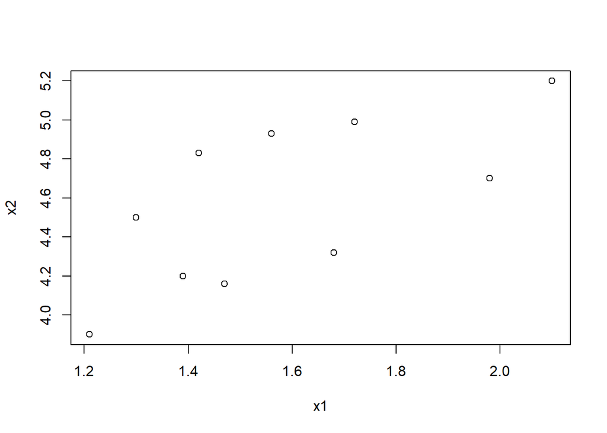

```r
example9_1<-read.csv('F:\\课件\\资源\\《R语言统计分析与应用》配套程序\\第九章\\example9_1.csv',header=TRUE)
attach(example9_1)

plot(x1,x2)
```

```r
cor(example9_1,method = 'pearson')
```

```
##           x1        x2
## x1 1.0000000 0.6807283
## x2 0.6807283 1.0000000
```

```r
cor.test(x1,x2,method = 'pearson')
```

```
##
##  Pearson's product-moment correlation
##
## data:  x1 and x2
## t = 2.6284, df = 8, p-value = 0.03025
## alternative hypothesis: true correlation is not equal to 0
## 95 percent confidence interval:
##  0.08943359 0.91722701
## sample estimates:
##       cor
## 0.6807283
```

```r
detach(example9_1)
```

```r
example9_3<-read.csv('F:\\课件\\资源\\《R语言统计分析与应用》配套程序\\第九章\\example9_3.csv',header=TRUE)
attach(example9_3)

cor(example9_3,method = 'spearman')
```

```
##           x         y
## x 1.0000000 0.7333333
## y 0.7333333 1.0000000
```

```r
cor.test(x,y,method = 'spearman')
```

```
##
##  Spearman's rank correlation rho
##
## data:  x and y
## S = 44, p-value = 0.02117
## alternative hypothesis: true rho is not equal to 0
## sample estimates:
##       rho
## 0.7333333
```

```r
detach(example9_3)
```

## 直线回归分析

### 直线回归分析介绍

**直线回归是用直线回归方程表示两个数量变量间的依存关系的统计分析方法，属于双变量分析的范畴。如果某一个变量随着另一个变量的变化而变化，并且他们的变化在直角坐标系中呈直线趋势，就可以用一个直线方程来定量的描述他们之间的数量依存关系**

**所谓的回归分析，就是依据相关关系的具体形态，选择一个合适的数学模型，来近似地表达变量间的平均关系**

[output not shown]

### 直线回归案例

**lm()函数只是R中一个众多关于回归的函数之一，lm()函数用于一般目的的回归分析函数**

**格式为： myfit<-lm(formula,data) formula:拟合的模型形式，data： 数据框**

```
R中常用的拟合模型有用的函数：

--summary() :展示详细的模型拟合结果
--anova() ：生成方差分析表
--plot() :拟合模型的诊断图
```

案例：体重与心脏横劲的关系

```r
example9_4<-read.csv('F:\\课件\\资源\\《R语言统计分析与应用》配套程序\\第九章\\example9_4.csv',header=TRUE)
head(example9_4)
```

```
##      x   y
## 1 25.5 9.2
## 2 19.5 7.8
## 3 24.0 9.4
## 4 20.5 8.6
## 5 25.0 9.0
## 6 22.0 8.8
```

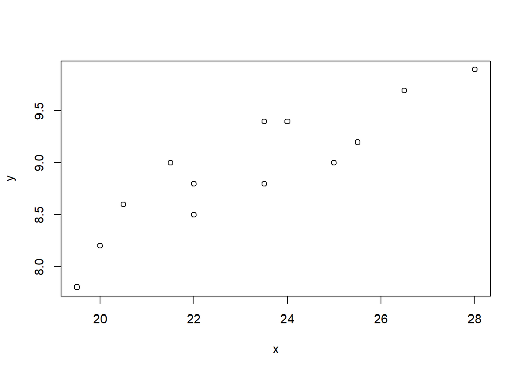

```r
attach(example9_4)
plot(x,y)
```

```r
fit<-lm(y~x)
anova(fit)
```

```
## Analysis of Variance Table
##
## Response: y
##           Df Sum Sq Mean Sq F value    Pr(>F)
## x          1 3.3444  3.3444   43.39 3.932e-05 ***
## Residuals 11 0.8479  0.0771
## ---
## Signif. codes:  0 '***' 0.001 '**' 0.01 '*' 0.05 '.' 0.1 ' ' 1
```

```r
summary(fit)
```

```
##
## Call:
## lm(formula = y ~ x)
##
## Residuals:
##     Min      1Q  Median      3Q     Max
## -0.3925 -0.2090 -0.0275  0.2034  0.3993
##
## Coefficients:
##             Estimate Std. Error t value Pr(>|t|)
## (Intercept)  4.21212    0.72280   5.828 0.000115 ***
## x            0.20412    0.03099   6.587 3.93e-05 ***
## ---
## Signif. codes:  0 '***' 0.001 '**' 0.01 '*' 0.05 '.' 0.1 ' ' 1
##
## Residual standard error: 0.2776 on 11 degrees of freedom
## Multiple R-squared:  0.7978, Adjusted R-squared:  0.7794
## F-statistic: 43.39 on 1 and 11 DF,  p-value: 3.932e-05
```